# Reproducible Research: Peer Assessment 1

## Set Global options - code chucks will always print.

opts_chunk$set(comment=NA, fig.width=6, fig.height=6 , echo=TRUE)

## load libraries as

```r
## get dplyr library
if (!"dplyr" %in% installed.packages()) install.packages(dplyr)
require(dplyr)
```

```r
if (!"ggplot2" %in% installed.packages()) install.packages(ggplot2)
require(ggplot2)
```

## Loading and preprocessing the data

```r
setwd("~/GitHub/RepData_PeerAssessment1")
unzip("activity.zip")
activity <- read.csv("~/GitHub/RepData_PeerAssessment1/activity.csv",colClasses="character")
activity$date <- as.Date(activity$date, format="%Y-%m-%d")
activity$steps <-as.numeric(activity$steps)
activity$interval <-as.numeric(activity$interval)
act.df = tbl_df(activity)
```

## What is mean total number of steps taken per day?

The histogram below shows the total number of steps taken each day during the two month period with unkownn values removed from the data set. The mean and median total number of steps taken each day is shown. Again, unknown values are removed

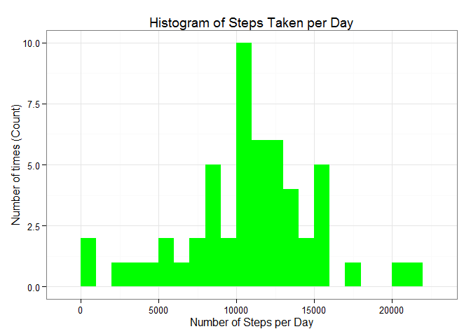

```r
#load
spd <- summarise(select(group_by(act.df,date),steps),TotalSteps=sum(steps,na.rm=TRUE))
spd <- filter(spd,TotalSteps !=0)
#plot
ggplot(spd, aes(x = TotalSteps)) +
  geom_histogram(fill = "green", binwidth = 1000) +
  labs(title="Histogram of Steps Taken per Day",
       x = "Number of Steps per Day", y = "Number of times (Count)") +
  theme_bw()
```

```r
#mean
spd.mean <- mean(spd$TotalSteps)
#median
spd.median <- median(spd$TotalSteps)
```

**mean is :** 10766,19

**median is :** 10765

## What is the average daily activity pattern?

The line graph below shows the average number of steps taken in each 5-minute interval over the two month period. The maximum average number of steps can be seen to have occured around 8:35 am.

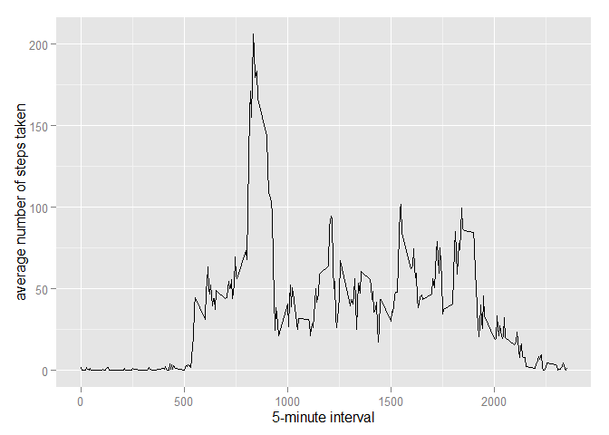

```r
spi <-summarise(select(group_by(act.df,interval),steps),meanSteps=mean(steps,na.rm=TRUE))


ggplot(data=spi, aes(x=interval, y=meanSteps)) +
  geom_line() +
  xlab("5-minute interval") +
  ylab("average number of steps taken")
```

```r
intmax <- filter(spi , meanSteps==max(meanSteps))
interval.max <-intmax[,1]
```

The interval with the max mean step is 835

## Imputing missing values

```r
sumNA<-sum(is.na(activity$steps))
```

From the complete dataset of 17,568 observations a total of 2304 are missing.

```r
join <- left_join(act.df,spi)
```

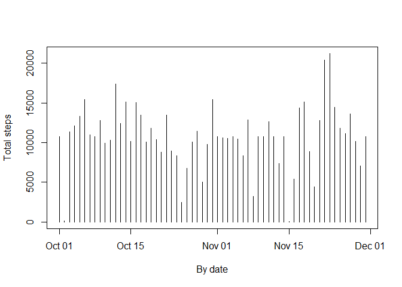

```r
NAreplaced<-mutate(join,Steps = (ifelse(is.na(steps), meanSteps, steps)))
sumstepsNA<-summarise(select(group_by(NAreplaced,date),Steps),totalSteps=sum(Steps,na.rm=TRUE))
plot(sumstepsNA$date,sumstepsNA$totalSteps,type="h",xlab="By date",ylab="Total steps")
```

```r
nasum<-summarise(sumstepsNA,mean = mean(totalSteps),median=median(totalSteps))
```

## Are there differences in activity patterns between weekdays and weekends?

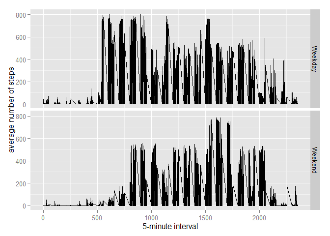

```r
NAreplaced.days<-mutate(NAreplaced,day=weekdays(date))
NAreplaced.newfactor<-mutate(NAreplaced.days,new=ifelse(day=="Saturday"|day=="Sunday","Weekend","Weekday"))
NAreplaced.newfactor$new<-as.factor(NAreplaced.newfactor$new)

sumsteps<-summarise(select(group_by(NAreplaced.newfactor,interval , new ,Steps),stepmean=mean(Steps,na.rm=TRUE)))


ggplot(sumsteps, aes(interval, stepmean)) +
  geom_line() +
  facet_grid(new ~ .) +
  xlab("5-minute interval") +
  ylab("average number of steps")
```